# Predicting The Weather

# Analysis

To continue with a transformation analysis, the box-cox method will be applied to determine the type of transformation needed. Since zero is within the boundaries a log transformation will be used.

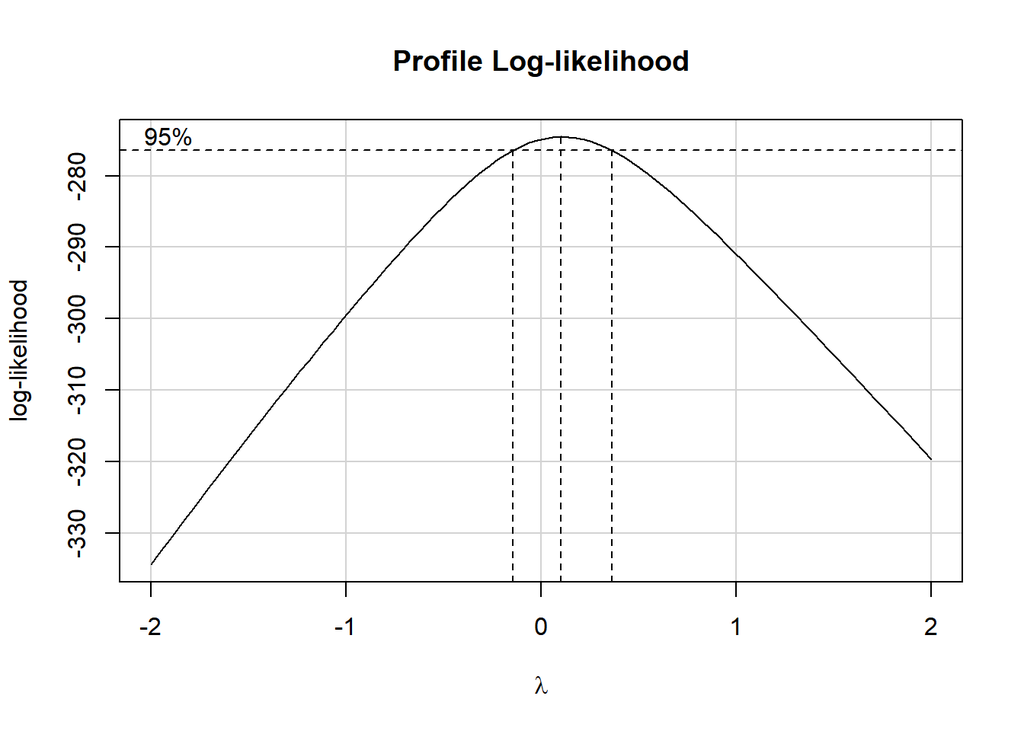

```r
boxCox(carprice.lm)
```

The diagnostic plots will tell us if the log transformation is appropriate. The linearity of the first plot is satisfie and so are the other requirements. This is a good fit for the data.

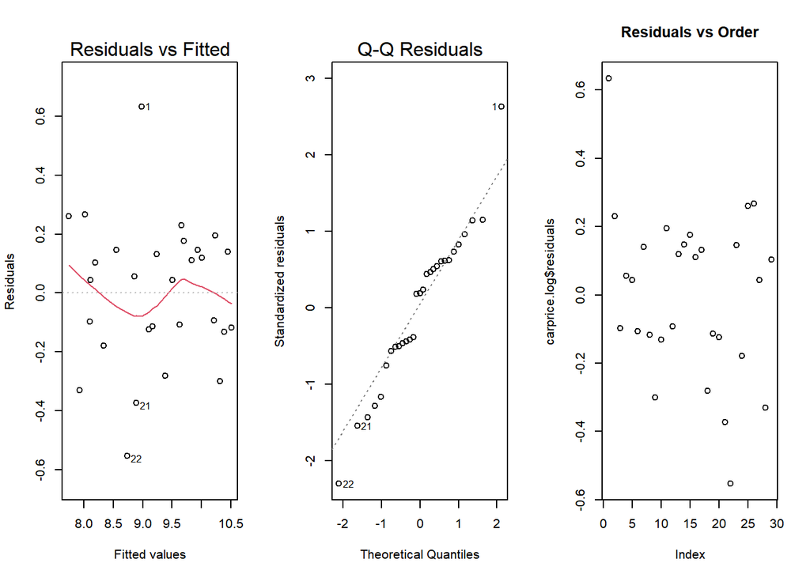

```r
par(mfrow=c(1,3))
plot(carprice.log,which=1:2)
plot(carprice.log$residuals, main="Residuals vs Order")
```

Running the linear transformation regression gives us the following output:

```r
summary(carprice.log) %>% pander()
```

|  | Estimate | Std. Error | t value | Pr(>\|t\|) |
| --- | --- | --- | --- | --- |
| **(Intercept)** | 10.62 | 0.08793 | 120.8 | 1.903e-38 |
| **mileage** | -9.275e-06 | 5.027e-07 | -18.45 | 7.788e-17 |

Fitting linear model: log(price) ~ mileage

| Observations | Residual Std. Error | $R^2$ | Adjusted $R^2$ |
| --- | --- | --- | --- |
| 29 | 0.2457 | 0.9265 | 0.9238 |

# Interpretation

The results of the regression analysis produce this equation

$$\underbrace{\hat{Y_i'}}_\text{Pred. log price} = 10.62 - 0.000009275
\underbrace{X_i}_\text{mileage}$$

This however is in logarithmic units and is therefore not useful for interpretation. Doing the math to return it to the original units produces the following equation.
$$\underbrace{\hat{Y_i}}_\text{Pred. price} = exp(10.62 - 0.000009275
\underbrace{X_i}_\text{mileage})$$

This is an interpretable equation that allows us to know how the price of a car is reducing in accordance with the mileage. For every increase of 10000 miles to the mileage, the price of the car decreases by 8.9%.

```r
(1-exp(-0.000009275*10000)) %>% pander()
```

*0.08858*